# Project: Investigate the IMDB Movies Dataset

- Introduction
- Data Wrangling
- Exploratory Data Analysis
- Conclusions

## Introduction

In this project, I will go through the data analysis process through working on a movies dataset from IMDB. This project is part of Udacity's Data Analyst Nanodegree.

### My research questions about this dataset are:

1. Who are the actors with largest number of movies?
2. What is the effect of number of votes on movie rating average?
3. What are the longest and shortest types of movies?
4. What type of movies are being produced every year? What are the most produced movies back in 1960 and in 2015?
5. How is the profit of Movie iIndustry changing through the years?

```python
# Import required libraries
import pandas as pd
import matplotlib.pyplot as plt
import numpy as np
%matplotlib inline
```

## Data Wrangling

In this section, data will be loaded and cleaned o start the analysis

```python
# Load your data and print out a few lines. Perform operations to inspect data
#   types and look for instances of missing or possibly errant data.
df_original = pd.read_csv("tmdb-movies.csv")
df_original.info()
```

```
<class 'pandas.core.frame.DataFrame'>
RangeIndex: 10866 entries, 0 to 10865
Data columns (total 21 columns):
id                      10866 non-null int64
imdb_id                 10856 non-null object
popularity              10866 non-null float64
budget                  10866 non-null int64
revenue                 10866 non-null int64
original_title          10866 non-null object
cast                    10790 non-null object
homepage                2936 non-null object
director                10822 non-null object
tagline                 8042 non-null object
keywords                9373 non-null object
overview                10862 non-null object
runtime                 10866 non-null int64
genres                  10843 non-null object
production_companies    9836 non-null object
release_date            10866 non-null object
vote_count              10866 non-null int64
vote_average            10866 non-null float64
release_year            10866 non-null int64
budget_adj              10866 non-null float64
revenue_adj             10866 non-null float64
dtypes: float64(4), int64(6), object(11)
memory usage: 1.7+ MB
```

```python
df_original.head()
```

|  | id | imdb_id | popularity | budget | revenue | original_title | cast | homepage | director | tagline | ... | overview | runtime | genres | production_companies | release_date | vote_count | vote_average | release_year | budget_adj | revenue_adj |
| --- | --- | --- | --- | --- | --- | --- | --- | --- | --- | --- | --- | --- | --- | --- | --- | --- | --- | --- | --- | --- | --- |
| 0 | 135397 | tt0369610 | 32.985763 | 150000000 | 1513528810 | Jurassic World | Chris Pratt\|Bryce Dallas Howard\|Irrfan Khan\|Vi... | http://www.jurassicworld.com/ | Colin Trevorrow | The park is open. | ... | Twenty-two years after the events of Jurassic ... | 124 | Action\|Adventure\|Science Fiction\|Thriller | Universal Studios\|Amblin Entertainment\|Legenda... | 6/9/15 | 5562 | 6.5 | 2015 | 1.379999e+08 | 1.392446e+09 |
| 1 | 76341 | tt1392190 | 28.419936 | 150000000 | 378436354 | Mad Max: Fury Road | Tom Hardy\|Charlize Theron\|Hugh Keays-Byrne\|Nic... | http://www.madmaxmovie.com/ | George Miller | What a Lovely Day. | ... | An apocalyptic story set in the furthest reach... | 120 | Action\|Adventure\|Science Fiction\|Thriller | Village Roadshow Pictures\|Kennedy Miller Produ... | 5/13/15 | 6185 | 7.1 | 2015 | 1.379999e+08 | 3.481613e+08 |
| 2 | 262500 | tt2908446 | 13.112507 | 110000000 | 295238201 | Insurgent | Shailene Woodley\|Theo James\|Kate Winslet\|Ansel... | http://www.thedivergentseries.movie/#insurgent | Robert Schwentke | One Choice Can Destroy You | ... | Beatrice Prior must confront her inner demons ... | 119 | Adventure\|Science Fiction\|Thriller | Summit Entertainment\|Mandeville Films\|Red Wago... | 3/18/15 | 2480 | 6.3 | 2015 | 1.012000e+08 | 2.716190e+08 |
| 3 | 140607 | tt2488496 | 11.173104 | 200000000 | 2068178225 | Star Wars: The Force Awakens | Harrison Ford\|Mark Hamill\|Carrie Fisher\|Adam D... | http://www.starwars.com/films/star-wars-episod... | J.J. Abrams | Every generation has a story. | ... | Thirty years after defeating the Galactic Empi... | 136 | Action\|Adventure\|Science Fiction\|Fantasy | Lucasfilm\|Truenorth Productions\|Bad Robot | 12/15/15 | 5292 | 7.5 | 2015 | 1.839999e+08 | 1.902723e+09 |
| 4 | 168259 | tt2820852 | 9.335014 | 190000000 | 1506249360 | Furious 7 | Vin Diesel\|Paul Walker\|Jason Statham\|Michelle ... | http://www.furious7.com/ | James Wan | Vengeance Hits Home | ... | Deckard Shaw seeks revenge against Dominic Tor... | 137 | Action\|Crime\|Thriller | Universal Pictures\|Original Film\|Media Rights ... | 4/1/15 | 2947 | 7.3 | 2015 | 1.747999e+08 | 1.385749e+09 |

5 rows × 21 columns

```python
df_original.describe()
```

|  | id | popularity | budget | revenue | runtime | vote_count | vote_average | release_year | budget_adj | revenue_adj |
| --- | --- | --- | --- | --- | --- | --- | --- | --- | --- | --- |
| count | 10866.000000 | 10866.000000 | 1.086600e+04 | 1.086600e+04 | 10866.000000 | 10866.000000 | 10866.000000 | 10866.000000 | 1.086600e+04 | 1.086600e+04 |
| mean | 66064.177434 | 0.646441 | 1.462570e+07 | 3.982332e+07 | 102.070863 | 217.389748 | 5.974922 | 2001.322658 | 1.755104e+07 | 5.136436e+07 |
| std | 92130.136561 | 1.000185 | 3.091321e+07 | 1.170035e+08 | 31.381405 | 575.619058 | 0.935142 | 12.812941 | 3.430616e+07 | 1.446325e+08 |
| min | 5.000000 | 0.000065 | 0.000000e+00 | 0.000000e+00 | 0.000000 | 10.000000 | 1.500000 | 1960.000000 | 0.000000e+00 | 0.000000e+00 |
| 25% | 10596.250000 | 0.207583 | 0.000000e+00 | 0.000000e+00 | 90.000000 | 17.000000 | 5.400000 | 1995.000000 | 0.000000e+00 | 0.000000e+00 |
| 50% | 20669.000000 | 0.383856 | 0.000000e+00 | 0.000000e+00 | 99.000000 | 38.000000 | 6.000000 | 2006.000000 | 0.000000e+00 | 0.000000e+00 |
| 75% | 75610.000000 | 0.713817 | 1.500000e+07 | 2.400000e+07 | 111.000000 | 145.750000 | 6.600000 | 2011.000000 | 2.085325e+07 | 3.369710e+07 |
| max | 417859.000000 | 32.985763 | 4.250000e+08 | 2.781506e+09 | 900.000000 | 9767.000000 | 9.200000 | 2015.000000 | 4.250000e+08 | 2.827124e+09 |

### Data Cleaning

After a quick look on the data, there some cleaning to be made:

- Remove unneeded columns: (`homepage`, `overview`, `tagline`)
- Remove rows containing null values
- Convert the `release_date` column from String to DateTime object

```python
# Remove unneeded columns
df_original.drop('homepage', axis=1, inplace=True)
df_original.drop('overview', axis=1, inplace=True)
df_original.drop('tagline', axis=1, inplace=True)

# Remove rows with null values
df_original.dropna(inplace=True)

# Convert the release_date column from String to DateTime object
df_original.release_date = pd.to_datetime(df_original.release_date)

# Check the results of data cleaning
df_original.info()
```

```
<class 'pandas.core.frame.DataFrame'>
Int64Index: 8665 entries, 0 to 10865
Data columns (total 18 columns):
id                      8665 non-null int64
imdb_id                 8665 non-null object
popularity              8665 non-null float64
budget                  8665 non-null int64
revenue                 8665 non-null int64
original_title          8665 non-null object
cast                    8665 non-null object
director                8665 non-null object
keywords                8665 non-null object
runtime                 8665 non-null int64
genres                  8665 non-null object
production_companies    8665 non-null object
release_date            8665 non-null datetime64[ns]
vote_count              8665 non-null int64
vote_average            8665 non-null float64
release_year            8665 non-null int64
budget_adj              8665 non-null float64
revenue_adj             8665 non-null float64
dtypes: datetime64[ns](1), float64(4), int64(6), object(7)
memory usage: 1.3+ MB
```

## Exploratory Data Analysis

> Before exploring the dataset, there is useful finction I want to use. Since there are some columns with cells containing multiple values such as: `genres` and `cast`, we need to have a way to split these values into different cells to make it easy on us to analyze.

```python
# This function was taken from here
# https://gist.github.com/jlln/338b4b0b55bd6984f883

def splitDataFrameList(df,target_column,separator):
    ''' df = dataframe to split,
    target_column = the column containing the values to split
    separator = the symbol used to perform the split

    returns: a dataframe with each entry for the target column separated, with each element moved into a new row.
    The values in the other columns are duplicated across the newly divided rows.
    '''
    def splitListToRows(row,row_accumulator,target_column,separator):
        split_row = row[target_column].split(separator)
        for s in split_row:
            new_row = row.to_dict()
            new_row[target_column] = s
            row_accumulator.append(new_row)
    new_rows = []
    df.apply(splitListToRows,axis=1,args = (new_rows,target_column,separator))
    new_df = pd.DataFrame(new_rows)
    return new_df
```

### Research Question 1: Who are the actors with largest number of movies?

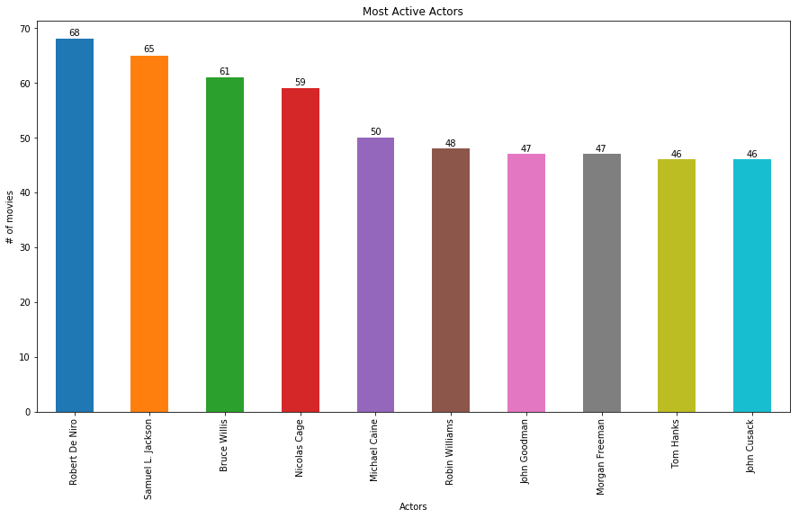

```python
# First we use the function above to split actors into multiple rows.
df_cast_expanded = splitDataFrameList(df_original, "cast", "|")

# Then, we gat a list of top 10 actors with larget number of movies they participated in
most_active_actors = df_cast_expanded.groupby("cast")["cast"].count().sort_values(ascending=False).head(10)

# Start plotting
plt.figure()
most_active_actors_plot = most_active_actors.plot(kind="bar", title="Most Active Actors", figsize=(15,8));
plt.xlabel("Actors")
plt.ylabel("# of movies")

# This loop below to add value labels above the bars is taken from stackoverflow
# https://stackoverflow.com/questions/25447700/annotate-bars-with-values-on-pandas-bar-plots
for p in most_active_actors_plot.patches:
    most_active_actors_plot.annotate(str(p.get_height()), (p.get_x() + p.get_width()/2 - 0.08, p.get_height() * 1.01))

plt.show()
```

```python
most_active_actors
```

```
cast
Robert De Niro       68
Samuel L. Jackson    65
Bruce Willis         61
Nicolas Cage         59
Michael Caine        50
Robin Williams       48
John Goodman         47
Morgan Freeman       47
Tom Hanks            46
John Cusack          46
Name: cast, dtype: int64
```

### Research Question 2: What is the effect of number of votes on movie rating average?

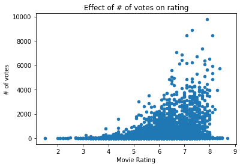

```python
# Compare votes count with average rating
plt.figure()
vote_vs_rating_plt = df_original.plot(x="vote_average", y="vote_count", title="Effect of # of votes on rating", kind="scatter");

plt.xlabel("Movie Rating")
plt.ylabel("# of votes")

plt.show()
```

As shown in the graph above, movies with higher rating tend to have more votes as more people watch them. We actually see this in real life; people sometimes watch movies based on movies rating so these movies get attention and in turn more votes.

## Research Question 3: What are the longest and shortest types of movies?

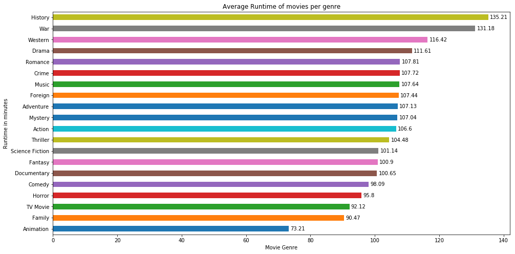

```python
# First we split genres into multiple rows.
df_genres_expanded = splitDataFrameList(df_original, "genres", "|")

# Then, we group by genres and find out the average run_time for every type of movie
genres_runtime = df_genres_expanded.groupby("genres")["runtime"].mean().sort_values(ascending=True)

# Start plotting
plt.figure()
genres_runtime_plot = genres_runtime.plot(kind="barh", title="Average Runtime of movies per genre", figsize=(16,8));
plt.xlabel("Movie Genre")
plt.ylabel("Runtime in minutes")

for p in genres_runtime_plot.patches:
    genres_runtime_plot.annotate(str(round(p.get_width(), 2)), (p.get_width() + 0.5, p.get_y() + 0.1))

plt.show()
```

It is pretty obvious from the graph that History and War movies are usually the longest while Animation movies are the shortest by almost half the duration.

## Research Question 4: What type of movies are being produced every year?

```
Text(0,0.5,'Number of movies')
```

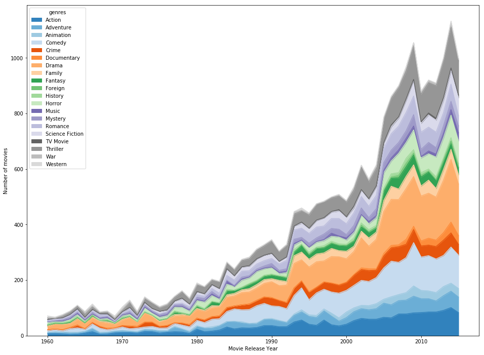

```python
# First, we use the expanded genres table, so we can group our data by release year and genres
df_year_genres = df_genres_expanded.groupby(["release_year", "genres"])["release_year"].count().unstack()

# Plot the results
plt.figure()
df_year_genres.plot(kind="area", stacked=True, figsize=(16,12), colormap="tab20c")
plt.xlabel("Movie Release Year")
plt.ylabel("Number of movies")
```

```python
df_genres_expanded.groupby(["release_year", "genres"])["release_year"].count().unstack()
```

| genres release_year | Action | Adventure | Animation | Comedy | Crime | Documentary | Drama | Family | Fantasy | Foreign | History | Horror | Music | Mystery | Romance | Science Fiction | TV Movie | Thriller | War | Western |
| --- | --- | --- | --- | --- | --- | --- | --- | --- | --- | --- | --- | --- | --- | --- | --- | --- | --- | --- | --- | --- |
| 1960 | 7.0 | 5.0 | NaN | 7.0 | 2.0 | NaN | 12.0 | 3.0 | 2.0 | NaN | 4.0 | 7.0 | 1.0 | NaN | 5.0 | 3.0 | NaN | 6.0 | 1.0 | 6.0 |
| 1961 | 7.0 | 6.0 | 1.0 | 8.0 | 2.0 | NaN | 16.0 | 3.0 | 1.0 | 1.0 | 3.0 | 3.0 | 2.0 | 1.0 | 6.0 | 2.0 | NaN | NaN | 2.0 | 3.0 |
| 1962 | 6.0 | 7.0 | NaN | 5.0 | 3.0 | NaN | 19.0 | 2.0 | 1.0 | 1.0 | 3.0 | 5.0 | 1.0 | 4.0 | 5.0 | 2.0 | NaN | 7.0 | 2.0 | 3.0 |
| 1963 | 4.0 | 7.0 | 1.0 | 13.0 | 4.0 | NaN | 13.0 | 3.0 | 2.0 | 2.0 | 4.0 | 8.0 | NaN | 5.0 | 8.0 | 2.0 | NaN | 10.0 | 1.0 | 2.0 |
| 1964 | 5.0 | 5.0 | 2.0 | 16.0 | 10.0 | NaN | 20.0 | 4.0 | 3.0 | 1.0 | 3.0 | 6.0 | 5.0 | 4.0 | 9.0 | 4.0 | NaN | 9.0 | 3.0 | 1.0 |
| 1965 | 9.0 | 6.0 | 1.0 | 7.0 | 2.0 | NaN | 18.0 | 3.0 | NaN | NaN | 4.0 | 4.0 | 2.0 | 3.0 | 5.0 | 1.0 | 1.0 | 10.0 | 7.0 | 4.0 |
| 1966 | 14.0 | 11.0 | 2.0 | 15.0 | 5.0 | 1.0 | 15.0 | 6.0 | 2.0 | 2.0 | 2.0 | 3.0 | NaN | 6.0 | 5.0 | 6.0 | NaN | 8.0 | 4.0 | 7.0 |
| 1967 | 5.0 | 6.0 | 1.0 | 15.0 | 6.0 | 1.0 | 15.0 | 3.0 | 3.0 | NaN | NaN | 4.0 | 4.0 | 2.0 | 11.0 | 3.0 | NaN | 4.0 | 1.0 | 2.0 |
| 1968 | 6.0 | 5.0 | 2.0 | 8.0 | 5.0 | NaN | 19.0 | 5.0 | 5.0 | NaN | 3.0 | 4.0 | 3.0 | 4.0 | 6.0 | 4.0 | NaN | 5.0 | 4.0 | 1.0 |
| 1969 | 10.0 | 5.0 | 2.0 | 8.0 | 3.0 | NaN | 12.0 | 3.0 | 2.0 | NaN | 3.0 | NaN | 2.0 | 1.0 | 3.0 | 3.0 | 1.0 | 3.0 | 3.0 | 7.0 |
| 1970 | 11.0 | 6.0 | 2.0 | 12.0 | 4.0 | 2.0 | 19.0 | 3.0 | 3.0 | 1.0 | 3.0 | 5.0 | 3.0 | 3.0 | 6.0 | 2.0 | 1.0 | 4.0 | 5.0 | 8.0 |
| 1971 | 11.0 | 5.0 | 1.0 | 8.0 | 10.0 | NaN | 30.0 | 2.0 | 2.0 | NaN | 3.0 | 7.0 | 1.0 | 6.0 | 9.0 | 6.0 | 1.0 | 17.0 | 4.0 | 5.0 |
| 1972 | 9.0 | 5.0 | 1.0 | 12.0 | 6.0 | NaN | 16.0 | 1.0 | 1.0 | NaN | NaN | 8.0 | 1.0 | 4.0 | 5.0 | 4.0 | NaN | 10.0 | NaN | 5.0 |
| 1973 | 15.0 | 5.0 | 3.0 | 8.0 | 17.0 | 1.0 | 31.0 | 4.0 | 1.0 | NaN | 2.0 | 15.0 | 1.0 | 7.0 | 3.0 | 6.0 | 1.0 | 16.0 | NaN | 4.0 |
| 1974 | 14.0 | 7.0 | 1.0 | 11.0 | 15.0 | 1.0 | 20.0 | 2.0 | 3.0 | NaN | 1.0 | 8.0 | 1.0 | 5.0 | 3.0 | 5.0 | 1.0 | 20.0 | 1.0 | 2.0 |
| 1975 | 9.0 | 8.0 | 1.0 | 9.0 | 6.0 | 1.0 | 16.0 | 1.0 | 4.0 | NaN | 3.0 | 8.0 | 3.0 | 8.0 | 1.0 | 10.0 | NaN | 12.0 | 2.0 | 3.0 |
| 1976 | 12.0 | 6.0 | NaN | 10.0 | 8.0 | 1.0 | 22.0 | 2.0 | NaN | NaN | 2.0 | 9.0 | 3.0 | 7.0 | 5.0 | 5.0 | 1.0 | 17.0 | 2.0 | 3.0 |
| 1977 | 14.0 | 15.0 | 5.0 | 10.0 | 2.0 | 1.0 | 23.0 | 6.0 | 9.0 | NaN | 4.0 | 14.0 | 3.0 | 5.0 | 4.0 | 10.0 | NaN | 12.0 | 4.0 | 1.0 |
| 1978 | 13.0 | 10.0 | 2.0 | 13.0 | 6.0 | 2.0 | 26.0 | 5.0 | 4.0 | NaN | 2.0 | 19.0 | 3.0 | 7.0 | 5.0 | 15.0 | 3.0 | 22.0 | 4.0 | 1.0 |
| 1979 | 8.0 | 8.0 | NaN | 16.0 | 8.0 | NaN | 30.0 | 4.0 | NaN | NaN | 3.0 | 11.0 | 4.0 | 4.0 | 8.0 | 10.0 | NaN | 16.0 | 3.0 | 3.0 |
| 1980 | 23.0 | 12.0 | NaN | 20.0 | 8.0 | NaN | 31.0 | 4.0 | 6.0 | 2.0 | 4.0 | 16.0 | 4.0 | 8.0 | 9.0 | 11.0 | 1.0 | 24.0 | 2.0 | 5.0 |
| 1981 | 14.0 | 12.0 | 3.0 | 18.0 | 9.0 | 1.0 | 30.0 | 4.0 | 3.0 | NaN | 4.0 | 23.0 | 3.0 | 10.0 | 8.0 | 8.0 | 1.0 | 25.0 | 1.0 | NaN |
| 1982 | 16.0 | 10.0 | 6.0 | 27.0 | 9.0 | 1.0 | 31.0 | 8.0 | 13.0 | 2.0 | 1.0 | 20.0 | 6.0 | 9.0 | 11.0 | 13.0 | 1.0 | 16.0 | 2.0 | 2.0 |
| 1983 | 20.0 | 14.0 | 3.0 | 24.0 | 10.0 | NaN | 33.0 | 3.0 | 10.0 | 1.0 | 1.0 | 12.0 | 4.0 | 5.0 | 13.0 | 16.0 | 1.0 | 24.0 | 1.0 | 1.0 |
| 1984 | 31.0 | 20.0 | NaN | 36.0 | 14.0 | 1.0 | 36.0 | 9.0 | 15.0 | NaN | 5.0 | 18.0 | 11.0 | 4.0 | 17.0 | 23.0 | 1.0 | 21.0 | 3.0 | NaN |
| 1985 | 24.0 | 26.0 | 2.0 | 44.0 | 11.0 | NaN | 36.0 | 9.0 | 12.0 | NaN | NaN | 13.0 | 1.0 | 3.0 | 19.0 | 16.0 | NaN | 21.0 | 2.0 | 2.0 |
| 1986 | 28.0 | 17.0 | 5.0 | 43.0 | 18.0 | NaN | 44.0 | 10.0 | 8.0 | NaN | 2.0 | 24.0 | 5.0 | 7.0 | 21.0 | 16.0 | NaN | 22.0 | 4.0 | 1.0 |
| 1987 | 27.0 | 15.0 | 2.0 | 50.0 | 20.0 | NaN | 43.0 | 12.0 | 16.0 | NaN | 3.0 | 20.0 | 3.0 | 5.0 | 18.0 | 16.0 | 2.0 | 24.0 | 6.0 | 1.0 |
| 1988 | 29.0 | 13.0 | 4.0 | 62.0 | 19.0 | NaN | 44.0 | 13.0 | 12.0 | 1.0 | 3.0 | 31.0 | 3.0 | 6.0 | 18.0 | 18.0 | 1.0 | 30.0 | 5.0 | NaN |
| 1989 | 36.0 | 22.0 | 2.0 | 56.0 | 23.0 | 1.0 | 48.0 | 14.0 | 12.0 | 1.0 | 3.0 | 23.0 | 2.0 | 8.0 | 19.0 | 20.0 | NaN | 33.0 | 4.0 | 1.0 |
| 1990 | 36.0 | 22.0 | 4.0 | 45.0 | 30.0 | NaN | 57.0 | 11.0 | 13.0 | 1.0 | 3.0 | 23.0 | 2.0 | 13.0 | 18.0 | 18.0 | 1.0 | 44.0 | 2.0 | 3.0 |
| 1991 | 32.0 | 20.0 | 3.0 | 50.0 | 20.0 | 3.0 | 52.0 | 19.0 | 14.0 | 2.0 | 1.0 | 7.0 | 5.0 | 7.0 | 23.0 | 10.0 | NaN | 34.0 | 2.0 | 1.0 |
| 1992 | 32.0 | 15.0 | 2.0 | 48.0 | 23.0 | NaN | 62.0 | 13.0 | 12.0 | 2.0 | 4.0 | 14.0 | 5.0 | 9.0 | 30.0 | 13.0 | NaN | 42.0 | 1.0 | 2.0 |
| 1993 | 49.0 | 24.0 | 5.0 | 67.0 | 27.0 | NaN | 88.0 | 28.0 | 12.0 | 2.0 | 8.0 | 16.0 | 6.0 | 15.0 | 33.0 | 15.0 | NaN | 43.0 | 6.0 | 3.0 |
| 1994 | 56.0 | 29.0 | 8.0 | 79.0 | 24.0 | 2.0 | 75.0 | 28.0 | 23.0 | 3.0 | 3.0 | 11.0 | 3.0 | 10.0 | 33.0 | 18.0 | 4.0 | 40.0 | 3.0 | 8.0 |
| 1995 | 41.0 | 28.0 | 6.0 | 54.0 | 29.0 | NaN | 89.0 | 28.0 | 17.0 | 1.0 | 7.0 | 19.0 | NaN | 14.0 | 35.0 | 18.0 | 1.0 | 47.0 | 5.0 | 3.0 |
| 1996 | 37.0 | 28.0 | 8.0 | 81.0 | 19.0 | 2.0 | 91.0 | 28.0 | 21.0 | NaN | 4.0 | 17.0 | 3.0 | 13.0 | 39.0 | 23.0 | 2.0 | 57.0 | 2.0 | NaN |
| 1997 | 56.0 | 33.0 | 7.0 | 71.0 | 26.0 | 1.0 | 75.0 | 29.0 | 18.0 | 2.0 | 6.0 | 18.0 | 4.0 | 20.0 | 29.0 | 29.0 | 1.0 | 58.0 | 1.0 | NaN |
| 1998 | 39.0 | 31.0 | 11.0 | 76.0 | 31.0 | 2.0 | 95.0 | 29.0 | 19.0 | 1.0 | 6.0 | 18.0 | 11.0 | 17.0 | 36.0 | 23.0 | 2.0 | 49.0 | 3.0 | 1.0 |
| 1999 | 35.0 | 17.0 | 12.0 | 89.0 | 28.0 | 3.0 | 100.0 | 22.0 | 19.0 | 1.0 | 5.0 | 24.0 | 4.0 | 24.0 | 39.0 | 27.0 | 5.0 | 49.0 | 3.0 | 3.0 |
| 2000 | 41.0 | 24.0 | 20.0 | 78.0 | 28.0 | 2.0 | 84.0 | 27.0 | 19.0 | 2.0 | 4.0 | 15.0 | 8.0 | 12.0 | 39.0 | 24.0 | 1.0 | 53.0 | 4.0 | 2.0 |
| 2001 | 54.0 | 32.0 | 14.0 | 81.0 | 36.0 | 3.0 | 83.0 | 19.0 | 18.0 | 2.0 | 10.0 | 19.0 | 5.0 | 21.0 | 45.0 | 18.0 | 6.0 | 58.0 | 10.0 | 2.0 |
| 2002 | 62.0 | 35.0 | 12.0 | 90.0 | 39.0 | 6.0 | 108.0 | 24.0 | 15.0 | 7.0 | 8.0 | 28.0 | 2.0 | 24.0 | 41.0 | 23.0 | 2.0 | 80.0 | 7.0 | 1.0 |
| 2003 | 59.0 | 34.0 | 15.0 | 87.0 | 39.0 | 7.0 | 81.0 | 30.0 | 22.0 | NaN | 8.0 | 21.0 | 8.0 | 14.0 | 41.0 | 25.0 | 2.0 | 60.0 | 8.0 | 3.0 |
| 2004 | 59.0 | 38.0 | 18.0 | 94.0 | 27.0 | 5.0 | 106.0 | 26.0 | 17.0 | NaN | 7.0 | 28.0 | 7.0 | 25.0 | 48.0 | 31.0 | 3.0 | 63.0 | 6.0 | 7.0 |
| 2005 | 66.0 | 51.0 | 14.0 | 113.0 | 43.0 | 9.0 | 151.0 | 40.0 | 31.0 | 5.0 | 8.0 | 55.0 | 9.0 | 28.0 | 51.0 | 19.0 | 2.0 | 87.0 | 3.0 | 2.0 |
| 2006 | 64.0 | 47.0 | 29.0 | 128.0 | 48.0 | 9.0 | 166.0 | 47.0 | 29.0 | 4.0 | 12.0 | 46.0 | 11.0 | 28.0 | 59.0 | 25.0 | 7.0 | 95.0 | 7.0 | 1.0 |
| 2007 | 78.0 | 48.0 | 22.0 | 116.0 | 56.0 | 7.0 | 163.0 | 38.0 | 40.0 | 9.0 | 10.0 | 70.0 | 12.0 | 27.0 | 59.0 | 29.0 | 4.0 | 105.0 | 4.0 | 4.0 |
| 2008 | 78.0 | 50.0 | 27.0 | 126.0 | 48.0 | 18.0 | 183.0 | 44.0 | 34.0 | 12.0 | 19.0 | 57.0 | 15.0 | 27.0 | 66.0 | 44.0 | 5.0 | 100.0 | 15.0 | NaN |
| 2009 | 82.0 | 60.0 | 37.0 | 156.0 | 47.0 | 12.0 | 179.0 | 42.0 | 36.0 | 6.0 | 13.0 | 71.0 | 14.0 | 41.0 | 67.0 | 57.0 | 3.0 | 122.0 | 10.0 | NaN |
| 2010 | 83.0 | 50.0 | 30.0 | 120.0 | 40.0 | 18.0 | 162.0 | 36.0 | 32.0 | 6.0 | 10.0 | 53.0 | 5.0 | 26.0 | 62.0 | 32.0 | 5.0 | 100.0 | 5.0 | 6.0 |
| 2011 | 85.0 | 48.0 | 28.0 | 127.0 | 38.0 | 25.0 | 162.0 | 47.0 | 29.0 | 4.0 | 7.0 | 55.0 | 10.0 | 31.0 | 55.0 | 44.0 | 7.0 | 109.0 | 7.0 | 3.0 |
| 2012 | 85.0 | 40.0 | 30.0 | 121.0 | 45.0 | 23.0 | 155.0 | 31.0 | 29.0 | 3.0 | 10.0 | 71.0 | 11.0 | 23.0 | 56.0 | 43.0 | 7.0 | 117.0 | 7.0 | 3.0 |
| 2013 | 91.0 | 53.0 | 33.0 | 112.0 | 55.0 | 27.0 | 189.0 | 39.0 | 32.0 | NaN | 10.0 | 72.0 | 15.0 | 28.0 | 47.0 | 46.0 | 8.0 | 134.0 | 7.0 | 3.0 |
| 2014 | 101.0 | 59.0 | 29.0 | 130.0 | 51.0 | 39.0 | 226.0 | 36.0 | 29.0 | NaN | 13.0 | 81.0 | 20.0 | 30.0 | 62.0 | 49.0 | 9.0 | 147.0 | 18.0 | 4.0 |
| 2015 | 83.0 | 56.0 | 31.0 | 120.0 | 39.0 | 32.0 | 185.0 | 34.0 | 27.0 | NaN | 13.0 | 82.0 | 29.0 | 25.0 | 37.0 | 64.0 | 10.0 | 122.0 | 6.0 | 5.0 |

## Research Question 5: How is the profit of Movie iIndustry changing through the years?

In order for us to calculate this accurately, we need to look at the data again.

> **Note**: There are some movies with zero budget, this does not make sense and they need to be removed from the dataset

```python
# Show how much data is there with zero budget
df_original.query("budget == 0").info()
```

```
<class 'pandas.core.frame.DataFrame'>
Int64Index: 3938 entries, 30 to 10864
Data columns (total 18 columns):
id                      3938 non-null int64
imdb_id                 3938 non-null object
popularity              3938 non-null float64
budget                  3938 non-null int64
revenue                 3938 non-null int64
original_title          3938 non-null object
cast                    3938 non-null object
director                3938 non-null object
keywords                3938 non-null object
runtime                 3938 non-null int64
genres                  3938 non-null object
production_companies    3938 non-null object
release_date            3938 non-null datetime64[ns]
vote_count              3938 non-null int64
vote_average            3938 non-null float64
release_year            3938 non-null int64
budget_adj              3938 non-null float64
revenue_adj             3938 non-null float64
dtypes: datetime64[ns](1), float64(4), int64(6), object(7)
memory usage: 584.5+ KB
```

```python
df_original.query("budget == 0").head()
```

|  | id | imdb_id | popularity | budget | revenue | original_title | cast | director | keywords | runtime | genres | production_companies | release_date | vote_count | vote_average | release_year | budget_adj | revenue_adj |
| --- | --- | --- | --- | --- | --- | --- | --- | --- | --- | --- | --- | --- | --- | --- | --- | --- | --- | --- |
| 30 | 280996 | tt3168230 | 3.927333 | 0 | 29355203 | Mr. Holmes | Ian McKellen\|Milo Parker\|Laura Linney\|Hattie M... | Bill Condon | london\|detective\|sherlock holmes | 103 | Mystery\|Drama | BBC Films\|See-Saw Films\|FilmNation Entertainme... | 2015-06-19 | 425 | 6.4 | 2015 | 0.0 | 2.700677e+07 |
| 36 | 339527 | tt1291570 | 3.358321 | 0 | 22354572 | Solace | Abbie Cornish\|Jeffrey Dean Morgan\|Colin Farrel... | Afonso Poyart | thriller\|serial killer\|psychic\|fbi agent\|intrigue | 101 | Crime\|Drama\|Mystery | Eden Rock Media\|FilmNation Entertainment\|Flynn... | 2015-09-03 | 474 | 6.2 | 2015 | 0.0 | 2.056620e+07 |
| 72 | 284289 | tt2911668 | 2.272044 | 0 | 45895 | Beyond the Reach | Michael Douglas\|Jeremy Irvine\|Hanna Mangan Law... | Jean-Baptiste LÃ©onetti | desert\|hunting | 95 | Thriller | Furthur Films | 2015-04-17 | 81 | 5.5 | 2015 | 0.0 | 4.222338e+04 |
| 74 | 347096 | tt3478232 | 2.165433 | 0 | 0 | Mythica: The Darkspore | Melanie Stone\|Kevin Sorbo\|Adam Johnson\|Jake St... | Anne K. Black | sword\|magic\|sorcery\|necromancer\|woman director | 108 | Action\|Adventure\|Fantasy | Arrowstorm Entertainment | 2015-06-24 | 27 | 5.1 | 2015 | 0.0 | 0.000000e+00 |
| 75 | 308369 | tt2582496 | 2.141506 | 0 | 0 | Me and Earl and the Dying Girl | Thomas Mann\|RJ Cyler\|Olivia Cooke\|Connie Britt... | Alfonso Gomez-Rejon | tattoo\|high school\|leukemia\|friends\|parody | 105 | Comedy\|Drama | Indian Paintbrush | 2015-06-12 | 569 | 7.7 | 2015 | 0.0 | 0.000000e+00 |

```
Text(0,0.5,'Movies adjusted revenue in Billion dollars')
```

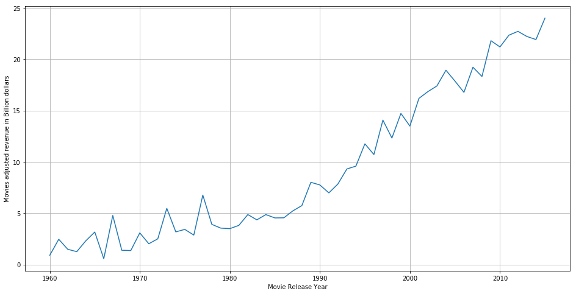

```python
# Get all non-zero budget movies
df_nonzero_budget = df_original[df_original.budget != 0]

# Group resulted dataset by release_year and find the adjusted revenue value in billions
profit_years_in_B = df_nonzero_budget.groupby("release_year")["revenue_adj"].sum()/1000000000

# Plot the results
plt.figure()
profit_years_in_B.plot(kind="line", figsize=(16,8), grid=True);
plt.xlabel("Movie Release Year")
plt.ylabel("Movies adjusted revenue in Billion dollars")
```

## Conclusions

```python
from subprocess import call
call(['python', '-m', 'nbconvert', 'Investigate_a_Dataset.ipynb'])
```

```
0
```